# Analysis of Child Abuse Cases and Reports from 2015-2019 in the United States

Sheamin Kim, LinhChi Le, Varsha Venkatesan

11/13/2022

# Dynamic Paragraph/Summary

These data sets will allow us to evaluate the extent to which child abuse affects United States residents. Our data was sourced by the U.S. Department of Health & Human Services / ACF. Being a government organization, this department is incredibly reliable for domestic data. The data was also collected in 2019 and updated in November 2021, meaning it is recent and mostly up to date. By analyzing the statistics, we hope to figure out which states need the most resources in preventing child abuse and increase their health, safety, and well-being. According to our data, the state with the most cases of child abuse was TX. The state with the least number of child abuse cases was ND. The year with the most number of child abuse cases was 2015. The year with the least number of child abuse cases was 2016. The average number cases per year was 1075. With these numbers, we are given a better idea of where government agencies as well as other third party organizations should be focusing or allocating their resources to reduce the average number of reported child abuse cases throughout the United States.

```r
summary_info
```

```
## [[1]]
## [1] "TX"
##
## [[2]]
## [1] "ND"
##
## [[3]]
## [1] 2015
##
## [[4]]
## [1] 2016
##
## $avgcases
## [1] 1075
```

# Summary Table

Figure 1. This table shows the average number of cases per state. We included the table because we thought it was important to include the locations of the cases. The table reveals how many cases of child abuse that there are in each state. Using this data, we found that Texas has the most number of cases, while North Dakota has the least number of cases.

Cases In Each State

| state | number of cases |
| --- | --- |
| AK | 16 |
| AL | 79 |
| AR | 212 |
| AZ | 213 |
| CA | 394 |
| CO | 198 |
| CT | 78 |
| DE | 29 |
| FL | 669 |
| GA | 393 |
| HI | 22 |
| IA | 34 |
| ID | 13 |
| IL | 373 |
| IN | 264 |
| KY | 44 |
| LA | 186 |
| MA | 105 |
| MD | 95 |
| ME | 49 |
| MI | 379 |
| MN | 85 |
| MS | 99 |
| NC | 89 |
| ND | 8 |
| NE | 23 |
| NH | 18 |
| NJ | 85 |
| OH | 297 |
| OR | 80 |
| PA | 94 |
| RI | 12 |
| SC | 104 |
| SD | 25 |
| TN | 124 |
| TX | 786 |
| UT | 30 |
| VA | 382 |
| VT | 14 |
| WA | 66 |
| WI | 219 |
| WV | 25 |

# Plots

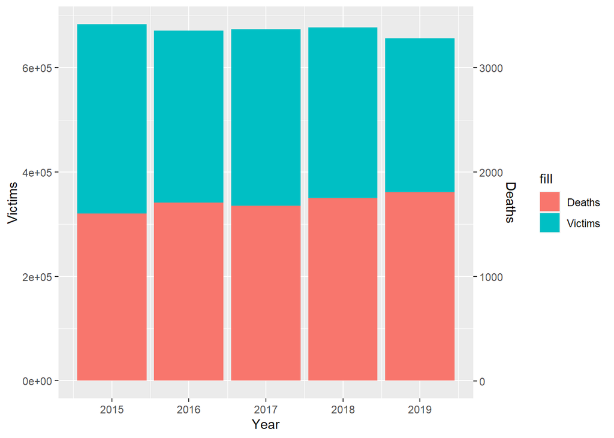

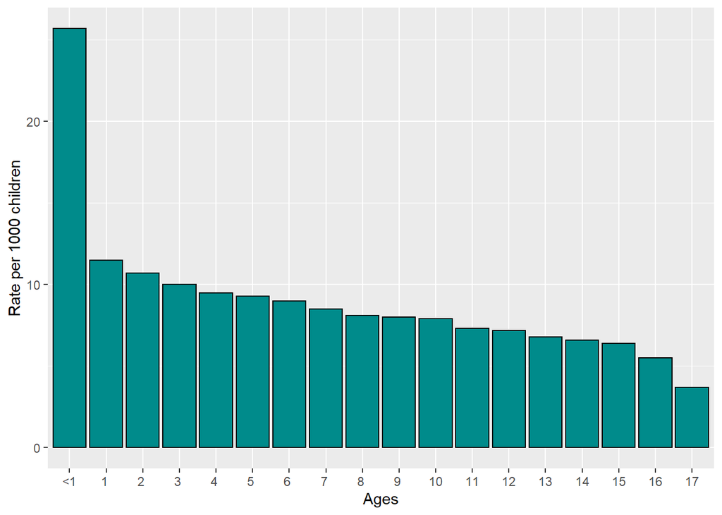

Figure 3. This histogram indicates the rate of abused children per 1000 children from 2015 to 2019, separated by age of children from <1 to 17 years of age. As children grow up, a decreasing trend of abuse cases can be seen. Most abused children are abused at younger than the age of one, and 17 year-olds are abused the least. This chart was included to visualize the different rate of cases by age of abused children.

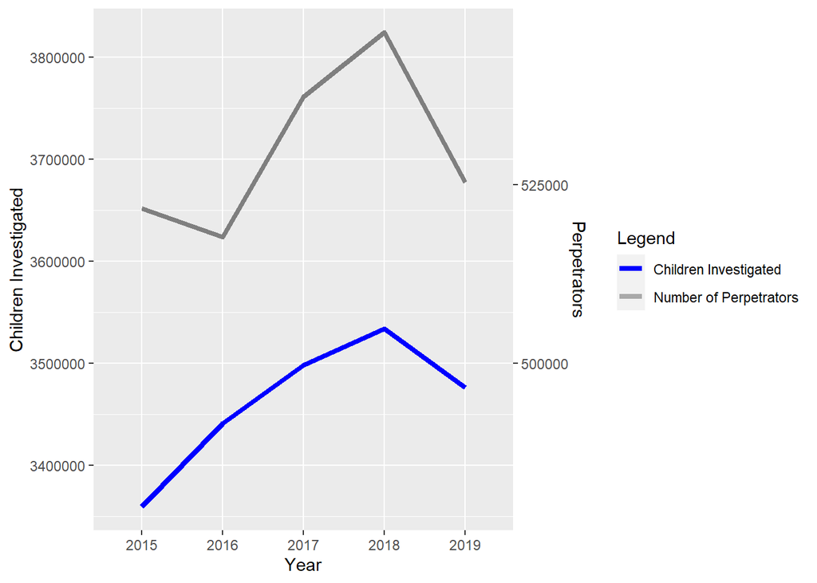